# In Class Exercise 4

In this in class exercise, I will explore using ggstatsplot and tidyverse packages on sample data to practice visual statistical analysis.

Jeremiah Lam https://sg.linkedin.com/in/jeremiah-lam-6156238a (School of Computing and Information Systems)https://scis.smu.edu.sg/  
2022-05-07

# Overview

In this in class exercise, I will explore using [**ggstatsplot**](https://www.rdocumentation.org/packages/ggstatsplot/versions/0.1.4) and tidyverse packages on sample data to practice visual statistical analysis.

The data is processed by using appropriate tidyverse and ggstatsplot family of packages.

# Getting Started

Before getting started, it is important to ensure that the required R packages have been installed. If yes, we will load the R packages. If they have yet to be installed, we will install the R packages and load them onto R environment.

The chunk code below will do the trick.

```r
packages = c('tidyverse', 'ggstatsplot', 'rstantools')

for(p in packages){
  if(!require(p, character.only = T)){
    install.packages(p)
  }
  library(p, character.only = T)
}
```

# Importing Data

The code chunk below imports *Exam_data.csv* from the data folder into R by using [`read_csv()`](https://readr.tidyverse.org/reference/read_delim.html) of [**readr**](https://readr.tidyverse.org/reference/index.html) package and saves it as a tibble data frame called *exam*.

```r
exam <- read_csv("data/Exam_data.csv")
```

# Working with ggstatsplot

### Anova stats plot (using parametric)

The code chunk below uses [**ggbetweenstats()**](https://indrajeetpatil.github.io/ggstatsplot/articles/web_only/ggbetweenstats.html) to build a visual for One-way ANOVA test on English scores by race.

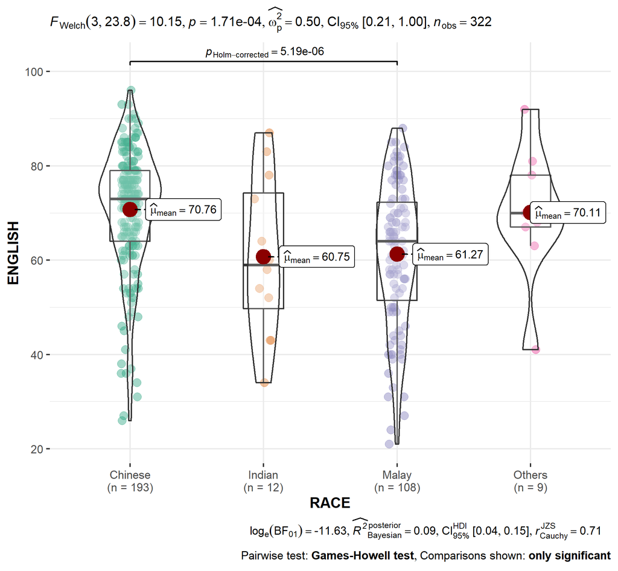

```r
ggbetweenstats(data = exam,
               x = RACE,
               y = ENGLISH
               )
```

### Anova stats plot (using non-parametric)

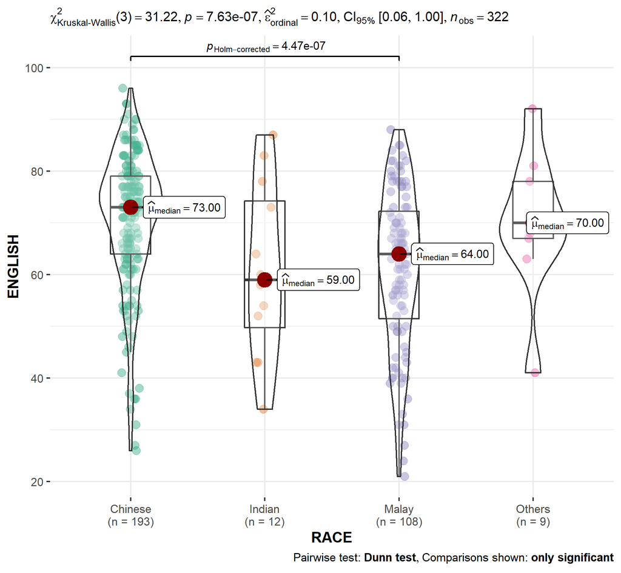

```r
ggbetweenstats(data = exam,
               x = RACE,
               y = ENGLISH,
               type = 'np'
               )
```

### Anova stats plot (using bayes)

The code chunk below uses [**ggbetweenstats()**](https://indrajeetpatil.github.io/ggstatsplot/articles/web_only/ggbetweenstats.html) to build a visual of four-sample test of English scores by race.

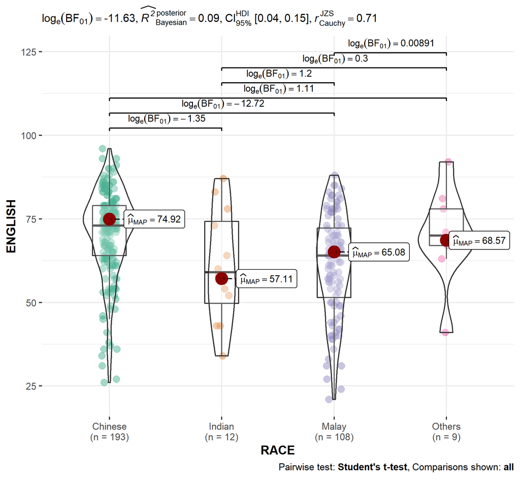

```r
set.seed(1234)

ggbetweenstats(data = exam,
               x = RACE,
               y = ENGLISH,
               type = 'bayes'
               )
```